# How to create a composite variable

Psychologists often ask participants multiple questions about the same topic or construct. For example, rather than ask participants one question about their self-esteem, psychologists might ask ten questions. This is good because there are measurement advantages (more reliability) associated with asking multiple questions about a topic compared to asking just one question.

But that means psychologists often need to create composite variables–variables that are composed of many other variables. For example, a self-esteem composite variable might be the mean of ten questions about self-esteem. In this notebook, I will show you a good way create composite variables in R.

We will use the ‘psych’ package to do this. The psych package contains lots of functions psychologists tend to use while analyzing data including creating composite variables. You can learn more about the psych package [here](http://personality-project.org/r/psych/).

In this tutorial we will download a datafile and use the psych package to create a composite variable.

First, download the datafile. We will use the PORL dataset for this.

```r
if (!require(foreign)){
  install.packages("foreign", dependencies = TRUE)
  require(foreign)
}
dataset = read.spss("https://osf.io/hwxre/download", to.data.frame=TRUE, use.value.labels = FALSE)
```

Next, we will download and install the psych pacakge.

```r
if (!require(psych)){
  install.packages("psych", dependencies = TRUE)
  require(psych)
}
```

Together, these three questions measure different aspects of the construct: Attitudes toward White people. So, we can combine them into a composite variable. In this case, we will compute average of those three variables.

Our first task is to create a data.frame with the variables we would like to calculate the average of. A data.frame is kinda like a spreasheet. It has columns and rows and allows us to access any row, column, or cell. In fact, the ‘dataset’ variable created above is a data.frame. So you’ve used these before but this might be the first time you explicitly create one.

We will use the data.frame() function to this. If we tell this function which variables we would like in the data.frame, it creates that data.frame for us.

```r
#create dataframe with only relevant variables to work with
whiteAttitudes <- data.frame (dataset$WPEOPLE, dataset$WMALES, dataset$WFEMALES)
```

Our data.frame is called whiteAttitudes. It has three columns: WPEOPLE, WMALES, WFEMALES

Next we need to tell the psych package if any the items in our scale need to be reverse coded. For example, if I was measuring self esteem I might ask participants if they agree with questions like: *I have a high opinion of myself* but also questions like *I do not think highly of myself*. The second question needs to be reversed scored because high scores on it represent low self-esteem. We want high scores to mean the same thing for every question in our scale.

For example, let’s say we were using a 5-point scale with 1 being the lowest and 5 being the highest. To reverse code this score we perform the following transformations:  
1 is changed to 5  
2 is changed to 4  
3 stays 3  
4 is changed to 2 and  
5 is changed to 1

However, in our composite variable (whiteAttitudes) there is no need to reverse code any variables. High scores on all three questions represent positive attitudes toward White people. But we still need to tell psych that.

Psych has a special function called make.keys() which creates the ‘scoring keys’ for the scale–including information about which items are reverse coded.

We pass the make.keys() function our data.frame (whiteAttitudes) and a list the keys. In the case, we have three items in the scale so the list we pass is: 1, 2, 3. Howver, if the second item needed to be reverse coded, we would pass: 1, -2, 3.

```r
#create the scoring keys (- if reverse scored)
my.keys <- make.keys(whiteAttitudes, list(whiteAttitudes=c(1,2,3)))
```

Next we tell psych to score the items for us. We use the scoreItems() function for this. We just tell scoreItems() the name of our data.frame (whiteAttitudes) and the name of our keys (my.keys).

```r
#score the items
my.scales <- scoreItems (my.keys, whiteAttitudes)
my.scores <- my.scales$scores
```

Now my.scales contains a lot of information about our scale and my.scores contains the means for each participant. So all we have left to do is add my.scores to ‘dataset’–the data.frame with all the PORL data.

```r
#place scores in main dataset
dataset$meanWhiteAttitudes <- my.scores[,]
```

```r
head(dataset$meanWhiteAttitudes)
```

```
[1]  40.00000  80.00000 100.00000  99.33333  30.00000  53.33333
```

One of the great advantages of the ‘psych’ package is that it allows us to easily check the reliability of a scale. All it takes is one line of code:

```r
my.scales$alpha
```

```
      whiteAttitudes
alpha      0.9422805
```

This number is the Cronbach’s alpha for our scale. It represents how well the items in the scale hang together. In other words, to what extent are they all measuring the same thing.

In R Markdown we can write that as: $\alpha$ = 0.9422805. Download the .rmd file with the same name as this .html file to see how to write fancy math symbols like alpha.

Now that we’ve scored the scale and we know its reliability, we can start to ask other questions as well.

For example, what is the mean?

```r
mean(dataset$meanWhiteAttitudes)
```

```
[1] 77.80945
```

What is the min and the max?

```r
#min
min(dataset$meanWhiteAttitudes)
```

```
[1] 6.666667
```

```r
#max
max(dataset$meanWhiteAttitudes)
```

```
[1] 100
```

What is the standard deviation? What is the min and the max?

```r
#min
sd(dataset$meanWhiteAttitudes)
```

```
[1] 19.9341
```

Now we have a better idea of the distribution of this variable. The mean is around 77 with a standard deviation of about 20. Scores range from about 7 all the up to 100. But, it would be nice to see the distribution visually. Well, R is great at visualizing data so let’s give it a shot.

We’ll create a density plot. A density plot gives an indication of the distribution of scores. The most common scores will be the highest points on the plot. The least common scores will be the lowest points. In practice, what happens is the mean is usually the highest point on the plot and often we see something that resembles a normal curve. Let’s see the distribution of the variable we just made!

We’ll use ggplot to do this. First, let’s load ggplot.

```r
if (!require(ggplot2)){
  install.packages("ggplot2", dependencies = TRUE)
  require(ggplot2)
}
```

Next, we’ll tell ggplot which variable we’d like it plot.

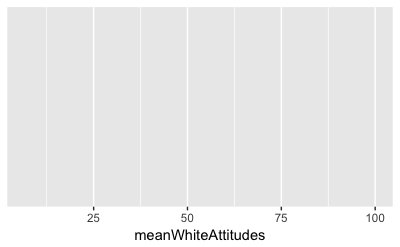

```r
ggplot(dataset, aes(meanWhiteAttitudes))
```

We have a blank grid!

That line of code tells ggplot that we’d like it to use the ‘meanWhiteAttitudes’ variable from the data.frame called ‘dataset.’  
But we didn’t tell ggplot what to do with that variable so it just made a blank grid with the ‘meanWhiteAttitudes’ variable on the x-axis.

Let’s tell ggplot we’d like to make a density plot.

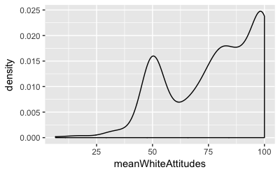

```r
ggplot(dataset, aes(meanWhiteAttitudes)) + geom_density()
```

We have a plot!

We tell ggplot to make a density plot by adding + geom_density() to the code. ggplot() allows us to add layers like geom_density() with the ‘+’ operator. We can add as many layers as we’d like. There are layers for different types of plots and layers for labels and so on. A quick google search will let you see what all the options are.

But….. R is great at visualizing data and this graph is kinda plain. Let’s spice it up.

First, let’s get rid of the gray background.

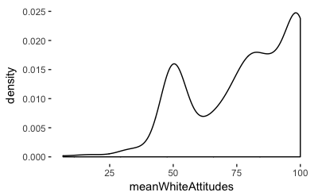

```r
ggplot(dataset, aes(meanWhiteAttitudes)) + geom_density() + theme(panel.background = element_rect(fill = "white", color = "white"))
```

Much better!

ggplot() let’s us change many elements of how the plot looks through the theme() layer. In this case, we told ggplot() to change the background (panel.background) to a white rectangle (element_rect(fill=“white”, color=“white”)).

Now let’s add the x and y axes. We’ll use the theme() layer to do this as well. We’ll tell ggplot() to add black lines for the x and y axes.

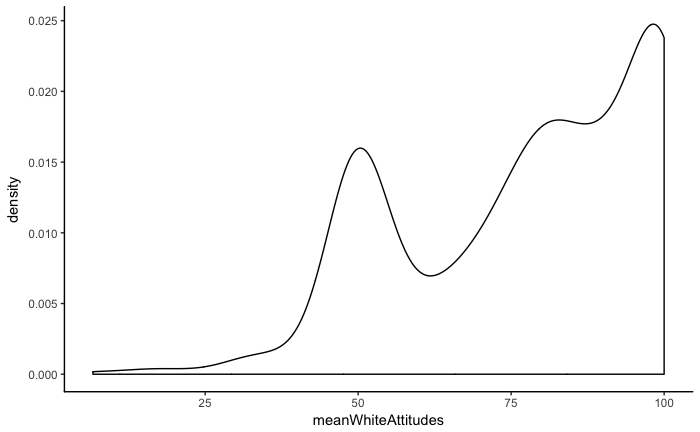

```r
ggplot(dataset, aes(meanWhiteAttitudes)) + geom_density() + theme(panel.background = element_rect(fill = "white", color = "white"), axis.line.x = element_line(color="black", size = .5), axis.line.y = element_line(color="black", size = .5))
```

Perfect!

But, now I wish it was more colorful. This is probably good for publication in a journal that doesn’t print in color. But this is totally boring on the web or in a presentation!

Let’s set the plot to blue. We’ll tell the density layer to fill with blue.

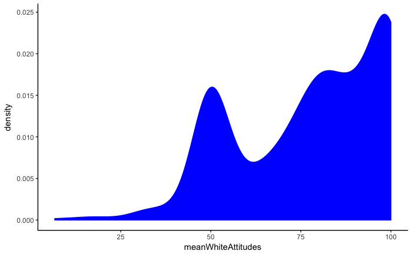

```r
ggplot(dataset, aes(meanWhiteAttitudes)) + geom_density(fill="blue", color="blue") + theme(panel.background = element_rect(fill = "white", color = "white"), axis.line.x = element_line(color="black", size = .5), axis.line.y = element_line(color="black", size = .5))
```

Looking much better! But now I don’t like the labels. meanWhiteAttitudes is a terrible label for the x-axis. We should give the x-axis a title that is more descriptive.

We’ll do that through the labs() layer.

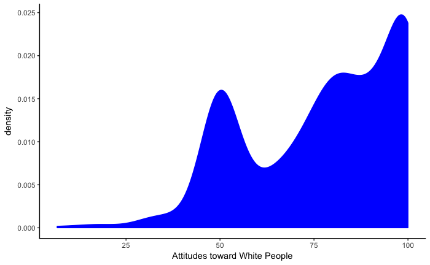

```r
ggplot(dataset, aes(meanWhiteAttitudes)) + geom_density(fill="blue", color="blue") + theme(panel.background = element_rect(fill = "white", color = "white"), axis.line.x = element_line(color="black", size = .5), axis.line.y = element_line(color="black", size = .5)) + labs(x = "Attitudes toward White People")
```

Great!

Now that the plot is looking a little better, let’s think about what it is telling us.

We know that the mean is about 77. But 77 isn’t the highest point on this plot! About 99 or 98 is. 77 mighe be the next highest hump. And there is also a third hump around 50.

Visually, this distribution looks like it might be bimodal. Bimodal means that there are two modes–or two most common responses. That isn’t true here but it’s close. There is a group of people that have very positive attitudes toward White people and another group that have very medium attitudes toward White people.

Let’s see if we can use the power of ggplot() to figure out who these different groups of people might be. What we’ll do is ask ggplot to draw the density plots for different groups of people in our dataset. Let’s start out by comparing the density plots for men and women. We do that by adding an aesthetic (aes) to the geom_density() layer.

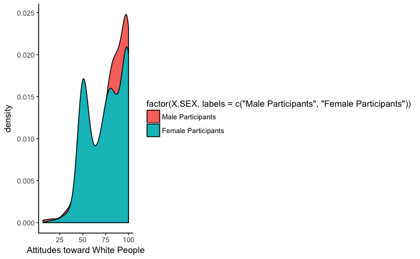

```r
ggplot(dataset, aes(meanWhiteAttitudes)) + geom_density(aes(fill=factor(X.SEX, labels=c("Male Participants", "Female Participants")))) + theme(panel.background = element_rect(fill = "white", color = "white"), axis.line.x = element_line(color="black", size = .5), axis.line.y = element_line(color="black", size = .5)) + labs(x = "Attitudes toward White People")
```

Great! But it’s hard to see what’s going on now. Everything is squished to make room for the legend.

Let’s remove remove what’s called the legend title. (factor(X.SEX, labels = c(….)))

We’ll use the theme layer to do this.

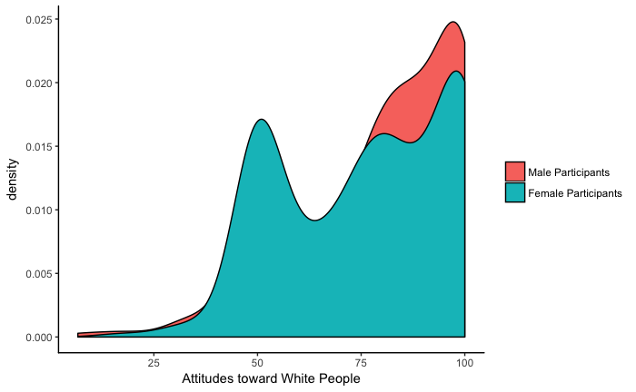

```r
ggplot(dataset, aes(meanWhiteAttitudes)) + geom_density(aes(fill=factor(X.SEX, labels=c("Male Participants", "Female Participants")))) + theme(panel.background = element_rect(fill = "white", color = "white"), axis.line.x = element_line(color="black", size = .5), axis.line.y = element_line(color="black", size = .5), legend.title = element_blank()) + labs(x = "Attitudes toward White People")
```

This is better. But it would better is density plots were transparent so we could see exactly how they overlap. We’ll add transparency via the geom_density() layer.

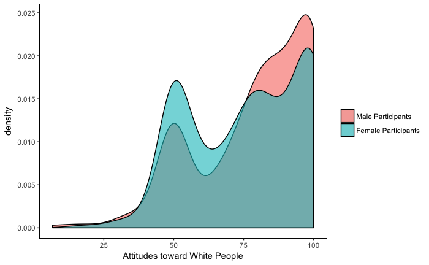

```r
ggplot(dataset, aes(meanWhiteAttitudes)) + geom_density(aes(fill=factor(X.SEX, labels=c("Male Participants", "Female Participants"))), alpha=0.6) + theme(panel.background = element_rect(fill = "white", color = "white"), axis.line.x = element_line(color="black", size = .5), axis.line.y = element_line(color="black", size = .5), legend.title = element_blank()) + labs(x = "Attitudes toward White People")
```

Now we can see that more male participants tended to have the most positive attitudes toward White people and more female participants tended to have more medium attitudes toward White people. I wouldn’t say this completely explains the bimodal pattern, but it seems to be part of the story.